# LAKE SUPERIOR CREEL SURVEY

## Report for Ashland from May 16, 2014 to September 30, 2014

#### Run on June 11, 2019 at 22:39

Table 1: Number of days by day type and assumed fishing day length (h) for each month during the sampling period. These values were used to expand sampled observations to entire population.

|  | DAY TYPE |  |  | Day |
| --- | --- | --- | --- | --- |
| MONTH | Weekday | Weekend | All Days | Length |
| May | 10 | 6 | 16 | 16 |
| Jun | 21 | 9 | 30 | 16 |
| Jul | 22 | 9 | 31 | 16 |
| Aug | 21 | 10 | 31 | 16 |
| Sep | 21 | 9 | 30 | 16 |
| All | 95 | 43 | 138 |  |

Table 2: Number of interviews (N) and hours of interviewed effort (Hrs) by state, day type, type of fishery, and month.

|  |  |  | May |  | Jun |  | Jul |  | Aug |  | Sep |  | All |  |
| --- | --- | --- | --- | --- | --- | --- | --- | --- | --- | --- | --- | --- | --- | --- |
| STATE | DAY TYPE | FISHERY | N | Hrs | N | Hrs | N | Hrs | N | Hrs | N | Hrs | N | Hrs |
| WI | Weekday | Cold-Open | 1 | 2 | 6 | 33 | 4 | 26 | 6 | 34 | 7 | 29 | 24 | 124 |
|  |  | Warm-Open | 14 | 111 | 46 | 283 | 13 | 74 | 22 | 117 | 8 | 50 | 103 | 634 |
|  |  | Bad R. | 0 | 0 | 0 | 0 | 0 | 0 | 0 | 0 | 0 | 0 | 0 | 0 |
|  |  | Non-Fishing | 1 | 6 | 0 | 0 | 11 | 33 | 6 | 18 | 2 | 2 | 20 | 59 |
|  |  | Tribal | 0 | 0 | 0 | 0 | 2 | 11 | 1 | 7 | 0 | 0 | 3 | 18 |
|  |  | All | 16 | 119 | 52 | 316 | 30 | 143 | 35 | 176 | 17 | 82 | 150 | 836 |
|  | Weekend | Cold-Open | 11 | 44 | 4 | 26 | 6 | 32 | 10 | 48 | 5 | 17 | 36 | 168 |
|  |  | Warm-Open | 18 | 70 | 29 | 129 | 31 | 143 | 18 | 79 | 10 | 74 | 106 | 495 |
|  |  | Bad R. | 0 | 0 | 0 | 0 | 0 | 0 | 1 | 5 | 0 | 0 | 1 | 5 |
|  |  | Non-Fishing | 10 | 23 | 3 | 13 | 7 | 9 | 8 | 11 | 12 | 58 | 40 | 114 |
|  |  | Tribal | 0 | 0 | 1 | 2 | 0 | 0 | 0 | 0 | 0 | 0 | 1 | 2 |
|  |  | All | 39 | 137 | 37 | 170 | 44 | 184 | 37 | 143 | 27 | 150 | 184 | 784 |
|  | All | Cold-Open | 12 | 46 | 10 | 59 | 10 | 58 | 16 | 82 | 12 | 47 | 60 | 292 |
|  |  | Warm-Open | 32 | 181 | 75 | 412 | 44 | 217 | 40 | 196 | 18 | 124 | 209 | 1130 |
|  |  | Bad R. | 0 | 0 | 0 | 0 | 0 | 0 | 1 | 5 | 0 | 0 | 1 | 5 |
|  |  | Non-Fishing | 11 | 29 | 3 | 13 | 18 | 42 | 14 | 30 | 14 | 61 | 60 | 174 |
|  |  | Tribal | 0 | 0 | 1 | 2 | 2 | 11 | 1 | 7 | 0 | 0 | 4 | 20 |
|  |  | All | 55 | 256 | 89 | 486 | 74 | 328 | 72 | 319 | 44 | 232 | 334 | 1620 |
| All | Weekday | Cold-Open | 1 | 2 | 6 | 33 | 4 | 26 | 6 | 34 | 7 | 29 | 24 | 124 |
|  |  | Warm-Open | 14 | 111 | 46 | 283 | 13 | 74 | 22 | 117 | 8 | 50 | 103 | 634 |
|  |  | Bad R. | 0 | 0 | 0 | 0 | 0 | 0 | 0 | 0 | 0 | 0 | 0 | 0 |
|  |  | Non-Fishing | 1 | 6 | 0 | 0 | 11 | 33 | 6 | 18 | 2 | 2 | 20 | 59 |
|  |  | Tribal | 0 | 0 | 0 | 0 | 2 | 11 | 1 | 7 | 0 | 0 | 3 | 18 |
|  |  | All | 16 | 119 | 52 | 316 | 30 | 143 | 35 | 176 | 17 | 82 | 150 | 836 |
|  | Weekend | Cold-Open | 11 | 44 | 4 | 26 | 6 | 32 | 10 | 48 | 5 | 17 | 36 | 168 |
|  |  | Warm-Open | 18 | 70 | 29 | 129 | 31 | 143 | 18 | 79 | 10 | 74 | 106 | 495 |
|  |  | Bad R. | 0 | 0 | 0 | 0 | 0 | 0 | 1 | 5 | 0 | 0 | 1 | 5 |
|  |  | Non-Fishing | 10 | 23 | 3 | 13 | 7 | 9 | 8 | 11 | 12 | 58 | 40 | 114 |
|  |  | Tribal | 0 | 0 | 1 | 2 | 0 | 0 | 0 | 0 | 0 | 0 | 1 | 2 |
|  |  | All | 39 | 137 | 37 | 170 | 44 | 184 | 37 | 143 | 27 | 150 | 184 | 784 |
|  | All | Cold-Open | 12 | 46 | 10 | 59 | 10 | 58 | 16 | 82 | 12 | 47 | 60 | 292 |
|  |  | Warm-Open | 32 | 181 | 75 | 412 | 44 | 217 | 40 | 196 | 18 | 124 | 209 | 1130 |
|  |  | Bad R. | 0 | 0 | 0 | 0 | 0 | 0 | 1 | 5 | 0 | 0 | 1 | 5 |
|  |  | Non-Fishing | 11 | 29 | 3 | 13 | 18 | 42 | 14 | 30 | 14 | 61 | 60 | 174 |
|  |  | Tribal | 0 | 0 | 1 | 2 | 2 | 11 | 1 | 7 | 0 | 0 | 4 | 20 |
|  |  | All | 55 | 256 | 89 | 486 | 74 | 328 | 72 | 319 | 44 | 232 | 334 | 1620 |

Table 3: Number of day sampled and total party-hours of pressure by month and day type (includes non-fishing effort).

|  | Weekday |  |  | Weekend |  |  | All Days |  |  |
| --- | --- | --- | --- | --- | --- | --- | --- | --- | --- |
|  | Days | Party Hours |  | Days | Party Hours |  | Days | Party Hours |  |
| MONTH | Sampled | Total | SD | Sampled | Total | SD | Sampled | Total | SD |
| May | 3 | 1641 | 501.8 | 3 | 3032 | 931.4 | 6 | 4673 | 1058.0 |
| Jun | 6 | 5430 | 2408.5 | 5 | 2077 | 881.0 | 11 | 7507 | 2564.5 |
| Jul | 5 | 4885 | 880.1 | 5 | 3963 | 1036.7 | 10 | 8849 | 1359.9 |
| Aug | 7 | 4408 | 704.4 | 4 | 3158 | 546.6 | 11 | 7566 | 891.6 |
| Sep | 7 | 2126 | 949.8 | 4 | 1536 | 458.9 | 11 | 3662 | 1054.8 |
| All | 28 | 18491 | 2868.0 | 21 | 13766 | 1796.6 | 49 | 32257 | 3384.3 |

Table 4: Total Party-hours, persons per party, total individual-hours, mean trip length, and total number of trips by waters, fishery type, month, and day type. ‘All’ results are shown only for those species found in multiple months.

|  |  |  |  |  |  | Persons |  |  | Mean |  |  |
| --- | --- | --- | --- | --- | --- | --- | --- | --- | --- | --- | --- |
|  |  |  |  | Party Hours |  | per | Ind. Hours |  | Trip | Trips |  |
| WATERS | FISHERY | MONTH | DAY TYPE | Total | SD | Party | Total | SD | Length | Total | SD |
| WI | Cold-Open | May | Weekday | 31 | 9.5 | 1.00 | 31 | 9.5 | 2.25 | 14 | 4.2 |
|  |  |  | Weekend | 971 | 298.1 | 1.78 | 1723 | 529.2 | 3.99 | 243 | 74.7 |
|  |  |  | All | 1002 | 298.3 | 1.75 | 1754 | 529.3 | 3.90 | 257 | 74.8 |
|  |  | Jun | Weekday | 566 | 251.1 | 2.57 | 1454 | 645.1 | 5.64 | 100 | 44.5 |
|  |  |  | Weekend | 322 | 136.5 | 1.85 | 594 | 251.9 | 6.59 | 49 | 20.7 |
|  |  |  | All | 888 | 285.8 | 2.31 | 2048 | 692.5 | 5.95 | 149 | 49.1 |
|  |  | Jul | Weekday | 885 | 159.4 | 2.00 | 1769 | 318.7 | 6.49 | 136 | 24.6 |
|  |  |  | Weekend | 683 | 178.7 | 2.31 | 1576 | 412.2 | 5.29 | 129 | 33.8 |
|  |  |  | All | 1568 | 239.4 | 2.13 | 3345 | 521.1 | 5.91 | 265 | 41.8 |
|  |  | Aug | Weekday | 845 | 135.1 | 2.64 | 2235 | 357.2 | 5.61 | 151 | 24.1 |
|  |  |  | Weekend | 1064 | 184.2 | 2.49 | 2645 | 457.8 | 4.82 | 221 | 38.2 |
|  |  |  | All | 1910 | 228.4 | 2.56 | 4880 | 580.7 | 5.14 | 372 | 45.2 |
|  |  | Sep | Weekday | 758 | 338.8 | 1.63 | 1236 | 552.3 | 4.18 | 182 | 81.1 |
|  |  |  | Weekend | 178 | 53.3 | 2.19 | 390 | 116.5 | 3.47 | 51 | 15.3 |
|  |  |  | All | 937 | 343.0 | 1.74 | 1626 | 564.5 | 4.02 | 233 | 82.5 |
|  |  | All | Weekday | 3085 | 470.7 | 2.18 | 6726 | 974.9 | 5.30 | 583 | 98.8 |
|  |  |  | Weekend | 3218 | 419.8 | 2.15 | 6928 | 858.3 | 4.64 | 693 | 94.1 |
|  |  |  | All | 6303 | 630.7 | 2.17 | 13654 | 1298.9 | 4.94 | 1276 | 136.4 |
|  | Warm-Open | May | Weekday | 1528 | 467.3 | 2.24 | 3416 | 1044.7 | 7.90 | 193 | 59.1 |
|  |  |  | Weekend | 1555 | 477.7 | 1.78 | 2764 | 849.0 | 3.91 | 398 | 122.3 |
|  |  |  | All | 3083 | 668.3 | 2.00 | 6180 | 1346.1 | 5.21 | 591 | 135.8 |
|  |  | Jun | Weekday | 4864 | 2157.4 | 2.29 | 11162 | 4950.7 | 6.19 | 786 | 348.6 |
|  |  |  | Weekend | 1573 | 667.2 | 2.29 | 3605 | 1529.4 | 4.44 | 354 | 150.1 |
|  |  |  | All | 6437 | 2258.2 | 2.29 | 14767 | 5181.6 | 5.65 | 1140 | 379.5 |
|  |  | Jul | Weekday | 2505 | 451.4 | 2.33 | 5831 | 1050.5 | 5.65 | 443 | 79.8 |
|  |  |  | Weekend | 3079 | 805.5 | 2.16 | 6655 | 1740.7 | 4.69 | 657 | 171.8 |
|  |  |  | All | 5585 | 923.4 | 2.24 | 12485 | 2033.1 | 5.08 | 1100 | 189.5 |
|  |  | Aug | Weekday | 2934 | 468.9 | 2.33 | 6849 | 1094.6 | 5.32 | 552 | 88.2 |
|  |  |  | Weekend | 1743 | 301.6 | 2.51 | 4365 | 755.5 | 4.55 | 383 | 66.3 |
|  |  |  | All | 4677 | 557.5 | 2.40 | 11215 | 1330.0 | 5.00 | 935 | 110.4 |
|  |  | Sep | Weekday | 1307 | 584.0 | 2.54 | 3322 | 1484.0 | 6.30 | 207 | 92.7 |
|  |  |  | Weekend | 760 | 227.2 | 1.37 | 1041 | 311.0 | 7.41 | 103 | 30.7 |
|  |  |  | All | 2068 | 626.6 | 2.11 | 4363 | 1516.2 | 6.67 | 310 | 97.6 |
|  |  | All | Weekday | 13139 | 2374.3 | 2.33 | 30580 | 5486.8 | 6.02 | 2182 | 384.4 |
|  |  |  | Weekend | 8710 | 1210.3 | 2.12 | 18430 | 2599.5 | 4.60 | 1895 | 269.0 |
|  |  |  | All | 21849 | 2665.0 | 2.24 | 49010 | 6071.4 | 5.36 | 4077 | 469.2 |
|  | Bad R. | Aug | Weekend | 102 | 17.7 | 4.00 | 410 | 70.9 | 4.63 | 22 | 3.8 |
|  | Non-Fishing | May | Weekday | 82 | 25.0 | 2.00 | 163 | 50.0 | 5.92 | 14 | 4.2 |
|  |  |  | Weekend | 506 | 155.6 | 1.70 | 863 | 265.2 | 2.29 | 221 | 67.9 |
|  |  |  | All | 588 | 157.6 | 1.75 | 1027 | 269.8 | 2.50 | 235 | 68.1 |
|  |  | Jun | Weekend | 153 | 64.8 | 2.83 | 433 | 183.7 | 4.17 | 37 | 15.5 |
|  |  | Jul | Weekday | 1115 | 200.9 | 2.23 | 2489 | 448.4 | 2.97 | 375 | 67.6 |
|  |  |  | Weekend | 201 | 52.5 | 1.97 | 396 | 103.6 | 1.33 | 151 | 39.4 |
|  |  |  | All | 1316 | 207.7 | 2.19 | 2885 | 460.2 | 2.50 | 526 | 78.2 |
|  |  | Aug | Weekday | 463 | 73.9 | 2.55 | 1177 | 188.1 | 3.07 | 151 | 24.1 |
|  |  |  | Weekend | 249 | 43.1 | 3.40 | 848 | 146.7 | 1.41 | 177 | 30.6 |
|  |  |  | All | 712 | 85.6 | 2.85 | 2025 | 238.6 | 2.17 | 327 | 38.9 |
|  |  | Sep | Weekday | 61 | 27.0 | 1.36 | 82 | 36.7 | 1.17 | 52 | 23.2 |
|  |  |  | Weekend | 597 | 178.5 | 3.01 | 1797 | 537.1 | 4.85 | 123 | 36.8 |
|  |  |  | All | 658 | 180.5 | 2.86 | 1879 | 538.3 | 3.76 | 175 | 43.5 |
|  |  | All | Weekday | 1720 | 217.2 | 2.27 | 3912 | 490.2 | 2.91 | 591 | 75.5 |
|  |  |  | Weekend | 1706 | 254.7 | 2.54 | 4337 | 651.7 | 2.41 | 708 | 93.3 |
|  |  |  | All | 3426 | 334.7 | 2.41 | 8249 | 815.5 | 2.64 | 1299 | 120.0 |
|  | Tribal | Jun | Weekend | 29 | 12.5 | 3.00 | 88 | 37.5 | 2.42 | 12 | 5.2 |
|  |  | Jul | Weekday | 380 | 68.5 | 2.33 | 886 | 159.6 | 5.58 | 68 | 12.3 |
|  |  | Aug | Weekday | 166 | 26.5 | 4.00 | 664 | 106.1 | 6.62 | 25 | 4.0 |
|  |  | All | Weekday | 546 | 73.4 | 2.84 | 1550 | 191.6 | 5.86 | 93 | 12.9 |
|  |  |  | Weekend | 29 | 12.5 | 3.00 | 88 | 37.5 | 2.42 | 12 | 5.2 |
|  |  |  | All | 576 | 74.5 | 2.85 | 1638 | 195.3 | 5.46 | 105 | 13.9 |
|  | All | May | Weekday | 1641 | 468.1 | 2.20 | 3611 | 1045.9 | 7.42 | 221 | 59.4 |
|  |  |  | Weekend | 3032 | 584.2 | 1.76 | 5350 | 1035.0 | 3.52 | 863 | 158.6 |
|  |  |  | All | 4673 | 748.6 | 1.92 | 8961 | 1471.4 | 4.31 | 1084 | 169.4 |
|  |  | Jun | Weekday | 5430 | 2172.0 | 2.32 | 12616 | 4992.6 | 6.13 | 886 | 351.4 |
|  |  |  | Weekend | 2077 | 684.2 | 2.27 | 4720 | 1561.3 | 4.60 | 451 | 152.4 |
|  |  |  | All | 7507 | 2277.2 | 2.31 | 17336 | 5231.0 | 5.61 | 1338 | 383.1 |
|  |  | Jul | Weekday | 4885 | 523.6 | 2.25 | 10974 | 1196.5 | 4.78 | 1023 | 108.1 |
|  |  |  | Weekend | 3963 | 826.8 | 2.18 | 8627 | 1791.9 | 4.23 | 937 | 179.5 |
|  |  |  | All | 8849 | 978.6 | 2.22 | 19601 | 2154.6 | 4.52 | 1959 | 209.5 |
|  |  | Aug | Weekday | 4408 | 494.2 | 2.48 | 10926 | 1171.5 | 5.02 | 878 | 94.6 |
|  |  |  | Weekend | 3158 | 356.5 | 2.62 | 8268 | 898.3 | 3.93 | 803 | 82.5 |
|  |  |  | All | 7566 | 609.4 | 2.54 | 19194 | 1476.2 | 4.50 | 1681 | 125.6 |
|  |  | Sep | Weekday | 2126 | 675.7 | 2.18 | 4641 | 1583.8 | 4.82 | 441 | 125.3 |
|  |  |  | Weekend | 1536 | 293.7 | 2.10 | 3228 | 631.5 | 5.54 | 277 | 50.3 |
|  |  |  | All | 3662 | 736.8 | 2.15 | 7869 | 1705.1 | 5.10 | 718 | 135.0 |
|  |  | All | Weekday | 18491 | 2431.4 | 2.31 | 42768 | 5597.5 | 5.36 | 3449 | 404.2 |
|  |  |  | Weekend | 13766 | 1306.2 | 2.19 | 30193 | 2815.2 | 4.13 | 3331 | 299.9 |
|  |  |  | All | 32257 | 2760.0 | 2.26 | 72961 | 6265.6 | 4.76 | 6780 | 503.3 |

Table 5: Total harvest and harvest rates based on fishery-specific angling hours by waters, fishery, species, month and day type. ‘All’ results are shown only for those species found in multiple months.

|  |  |  |  | Weekday |  |  | Weekend |  |  | All Days |  |  |
| --- | --- | --- | --- | --- | --- | --- | --- | --- | --- | --- | --- | --- |
|  |  |  |  | Harvest |  | Harvest/ | Harvest |  | Harvest/ | Harvest |  | Harvest/ |
| WATERS | FISHERY | SPECIES | MONTH | Number | SD | Angler-Hr | Number | SD | Angler-Hr | Number | SD | Angler-Hr |
| WI | Cold-Open | Lake Trout | Jun | 34 | 38.2 | 0.0236 | 146 | 83.3 | 0.2466 | 181 | 91.7 | 0.0883 |
|  |  |  | Jul | 614 | 238.9 | 0.3468 | 344 | 162.8 | 0.2184 | 958 | 289.1 | 0.2863 |
|  |  |  | Aug | 226 | 108.9 | 0.1010 | 641 | 218.7 | 0.2423 | 867 | 244.3 | 0.1776 |
|  |  |  | Sep | 104 | 103.2 | 0.0839 | -- | -- | -- | 104 | 103.2 | 0.0839 |
|  |  |  | All | 978 | 284.7 | 0.1460 | 1132 | 285.1 | 0.2350 | 2109 | 402.9 | 0.1832 |
|  |  | Siscowet | Aug | -- | -- | -- | 22 | 23.7 | 0.0084 | 22 | 23.7 | 0.0084 |
|  |  | Brown Trout | May | -- | -- | -- | 199 | 193.2 | 0.1155 | 199 | 193.2 | 0.1155 |
|  |  |  | Jun | 17 | 20.2 | 0.0118 | -- | -- | -- | 17 | 20.2 | 0.0118 |
|  |  |  | Jul | -- | -- | -- | 22 | 22.1 | 0.0137 | 22 | 22.1 | 0.0137 |
|  |  |  | Aug | -- | -- | -- | 22 | 22.7 | 0.0084 | 22 | 22.7 | 0.0084 |
|  |  |  | Sep | -- | -- | -- | 21 | 22.4 | 0.0527 | 21 | 22.4 | 0.0527 |
|  |  |  | All | 17 | 20.2 | 0.0118 | 263 | 197.1 | 0.0416 | 280 | 198.1 | 0.0360 |
|  |  | Coho | May | -- | -- | -- | 265 | 156.1 | 0.1540 | 265 | 156.1 | 0.1540 |
|  |  |  | Jun | 52 | 40.7 | 0.0355 | -- | -- | -- | 52 | 40.7 | 0.0355 |
|  |  |  | Sep | 52 | 45.5 | 0.0419 | 21 | 12.9 | 0.0527 | 72 | 47.3 | 0.0445 |
|  |  |  | All | 103 | 61.1 | 0.0384 | 286 | 156.6 | 0.1353 | 389 | 168.1 | 0.0811 |
|  |  | Chinook | Aug | -- | -- | -- | 22 | 22.5 | 0.0084 | 22 | 22.5 | 0.0084 |
|  |  | Rainbow Trout | May | -- | -- | -- | 22 | 24.0 | 0.0128 | 22 | 24.0 | 0.0128 |
|  |  | Walleye | Sep | -- | -- | -- | 10 | 9.8 | 0.0263 | 10 | 9.8 | 0.0263 |
|  |  | Northern Pike | May | -- | -- | -- | 22 | 23.5 | 0.0128 | 22 | 23.5 | 0.0128 |
|  | Warm-Open | Brown Trout | Jul | -- | -- | -- | 43 | 33.5 | 0.0065 | 43 | 33.5 | 0.0065 |
|  |  | Coho | May | 14 | 15.0 | 0.0040 | -- | -- | -- | 14 | 15.0 | 0.0040 |
|  |  | Walleye | May | 138 | 150.5 | 0.0404 | 66 | 54.4 | 0.0240 | 204 | 160.0 | 0.0331 |
|  |  |  | Jun | 464 | 287.7 | 0.0416 | 134 | 81.8 | 0.0372 | 598 | 299.1 | 0.0405 |
|  |  |  | Jul | 68 | 72.0 | 0.0117 | 387 | 189.2 | 0.0582 | 455 | 202.4 | 0.0365 |
|  |  |  | Aug | 100 | 60.1 | 0.0147 | 221 | 134.2 | 0.0506 | 321 | 147.1 | 0.0287 |
|  |  |  | Sep | -- | -- | -- | 82 | 39.4 | 0.0789 | 82 | 39.4 | 0.0789 |
|  |  |  | All | 771 | 337.9 | 0.0283 | 891 | 255.0 | 0.0483 | 1662 | 423.3 | 0.0364 |

[output cut: 55 more lines]

Table 6: Summary statistics of all measured fish by species, month, and whether clipped or not. ‘All’ results are shown only in those months where both clipped and unclipped fish were observed.

[output not shown]

Table 7: Summary statistics of measured fish by species, month, and whether clipped or not. Only species for which some fin-clipped fish were recorded are shown (otherwise see Table 6). ‘All’ results are shown only in those months where both clipped and unclipped fish were observed.

|  |  |  | Length (in.) |  |  |  |  |  |
| --- | --- | --- | --- | --- | --- | --- | --- | --- |
| SPECIES | MONTH | Clip | N | Mean | SE | Var | Min | Max |
| Lake Trout | Jun | 00: NONE | 9 | 22.46 | 1.06 | 10.18 | 18.2 | 27.4 |
|  | Jul | 00: NONE | 32 | 21.28 | 1.03 | 33.94 | 15.2 | 42.0 |
|  | Aug | 00: NONE | 29 | 21.57 | 0.71 | 14.55 | 15.3 | 28.1 |
|  |  | 01: AD | 1 | 16.10 | -- | -- | 16.1 | 16.1 |
|  |  | All | 30 | 21.38 | 0.71 | 15.04 | 15.3 | 28.1 |
|  | Sep | 00: NONE | 4 | 19.52 | 1.37 | 7.52 | 16.2 | 22.4 |
|  | All | 00: NONE | 74 | 21.44 | 0.54 | 21.76 | 15.2 | 42.0 |
|  |  | 01: AD | 1 | 16.10 | -- | -- | 16.1 | 16.1 |
|  |  | All | 75 | 21.37 | 0.54 | 21.85 | 15.2 | 42.0 |
| Brown Trout | May | 00: NONE | 2 | 17.50 | 1.50 | 4.50 | 16.0 | 19.0 |
|  |  | 01: AD | 7 | 20.20 | 0.90 | 5.68 | 15.6 | 23.4 |
|  |  | All | 9 | 19.60 | 0.83 | 6.24 | 15.6 | 23.4 |
|  | Jun | 01: AD | 1 | 22.50 | -- | -- | 22.5 | 22.5 |
|  | Jul | 00: NONE | 2 | 23.85 | 0.65 | 0.85 | 23.2 | 24.5 |
|  |  | 01: AD | 1 | 24.20 | -- | -- | 24.2 | 24.2 |
|  |  | All | 3 | 23.97 | 0.39 | 0.46 | 23.2 | 24.5 |
|  | Aug | 01: AD | 1 | 22.50 | -- | -- | 22.5 | 22.5 |
|  | Sep | 00: NONE | 1 | 23.00 | -- | -- | 23.0 | 23.0 |
|  |  | 01: AD | 1 | 19.90 | -- | -- | 19.9 | 19.9 |
|  |  | All | 2 | 21.45 | 1.55 | 4.80 | 19.9 | 23.0 |
|  | All | 00: NONE | 5 | 21.14 | 1.58 | 12.50 | 16.0 | 24.5 |
|  |  | 01: AD | 11 | 20.95 | 0.70 | 5.45 | 15.6 | 24.2 |
|  |  | All | 16 | 21.01 | 0.66 | 6.97 | 15.6 | 24.5 |

Table 8: Number of fish examined for fin clips by species, month, and clip. ‘All’ results are shown only for those species where both clipped and unclipped fish were observed.

|  |  | MONTH |  |  |  |  |  |
| --- | --- | --- | --- | --- | --- | --- | --- |
| SPECIES | CLIP | May | Jun | Jul | Aug | Sep | All |
| Lake Trout | 00: NONE |  | 9 | 34 | 39 | 4 | 86 |
|  | 01: AD |  |  |  | 1 |  | 1 |
|  | All |  | 9 | 34 | 40 | 4 | 87 |
| Siscowet | 00: NONE |  |  |  | 1 |  | 1 |
| Brown Trout | 00: NONE | 2 |  | 2 |  | 1 | 5 |
|  | 01: AD | 7 | 1 | 1 | 1 | 1 | 11 |
|  | All | 9 | 1 | 3 | 1 | 2 | 16 |
| Coho | 00: NONE | 13 | 3 |  |  | 4 | 20 |
| Chinook | 00: NONE |  |  |  | 1 |  | 1 |
| Walleye | 00: NONE | 13 | 38 | 31 | 20 | 9 | 111 |
| Yellow Perch | 00: NONE |  | 3 | 2 | 16 |  | 21 |
| Northern Pike | 00: NONE | 1 | 1 | 12 | 7 |  | 21 |
| Bluegill | 00: NONE |  | 1 |  | 2 |  | 3 |
| Black Crappie | 00: NONE |  | 3 |  |  |  | 3 |
| Rock Bass | 00: NONE |  |  |  | 1 |  | 1 |

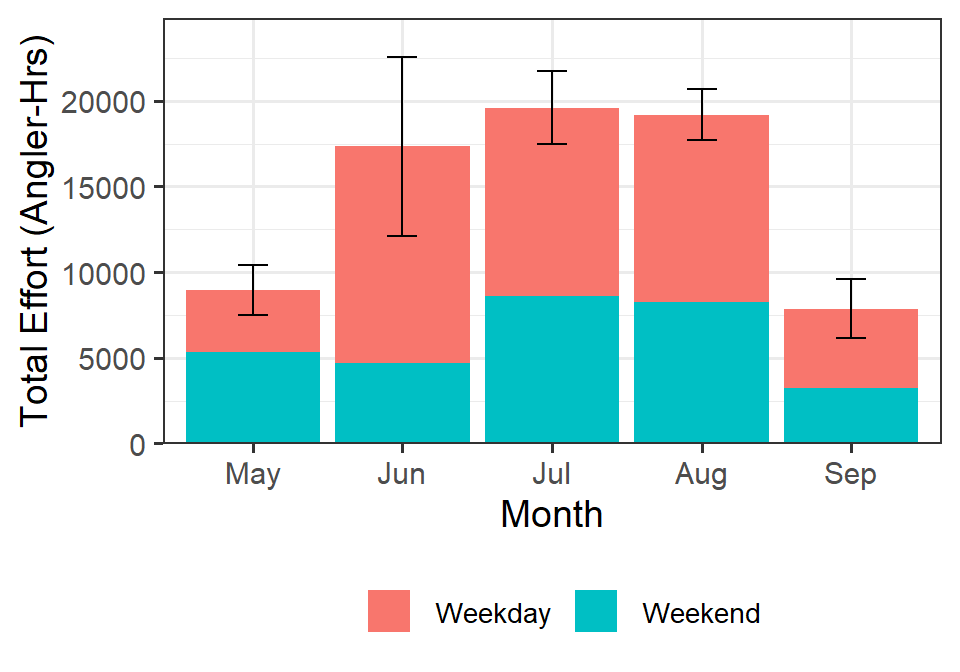

Figure 1: Total effort (angler-hours) for WISCONSIN waters only by month and day type. Errors bars are +/-1SD on total effort across both day types. Also see Table 4.

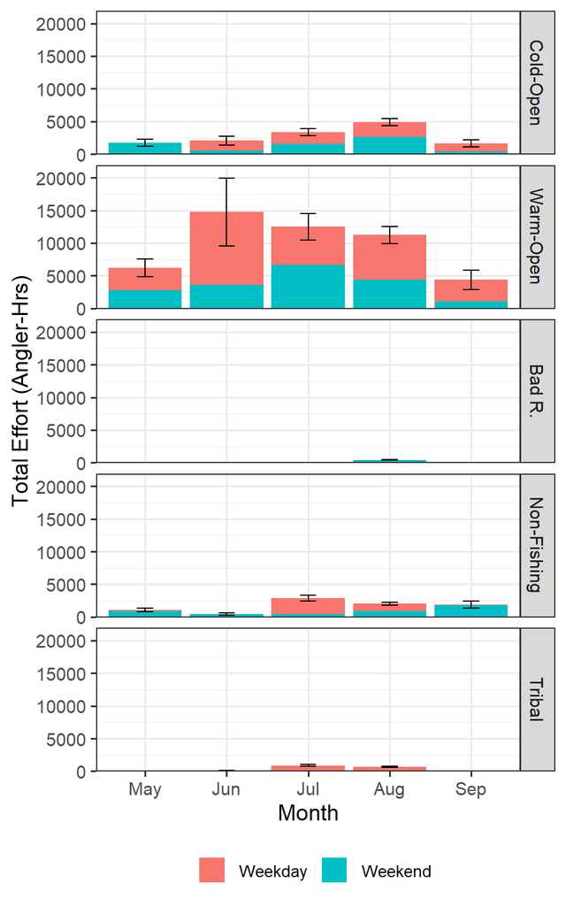

Figure 2: Total effort (angler-hours) for WISCONSIN waters only by month, fishery type, and day type. Errors bars are +/-1SD on total effort across both day types. Also see Table 4.

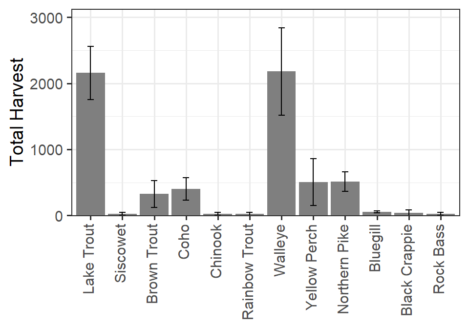

Figure 3: Total harvest of all species observed for WISCONSIN waters only. Errors bars are +/-1SD on total harvest. Also see Table 5.

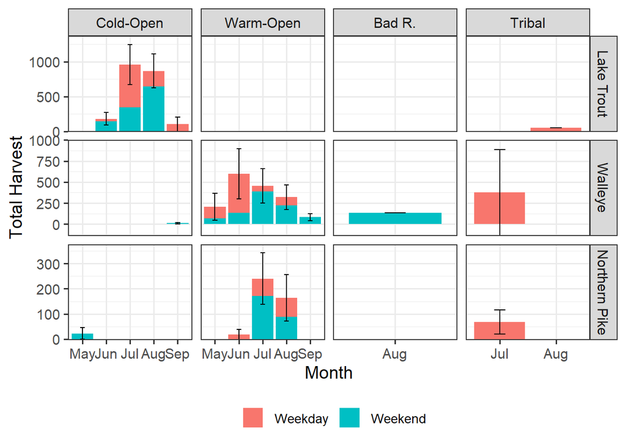

Figure 4: Total harvest of the most commonly harvested fish separated by fishery type, day type, and month for WISCONSIN waters only. Errors bars are +/-1SD on the total harvest across both day types. Also see Table 5.

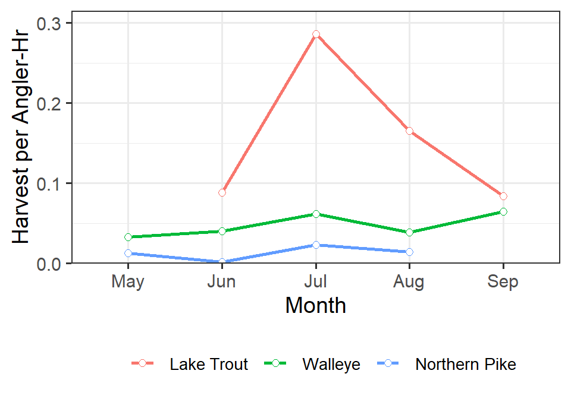

Figure 5: Harvest rate (total harvest per angler-hour) by month of the most commonly harvested fish for WISCONSIN waters only. Also see Table 5.

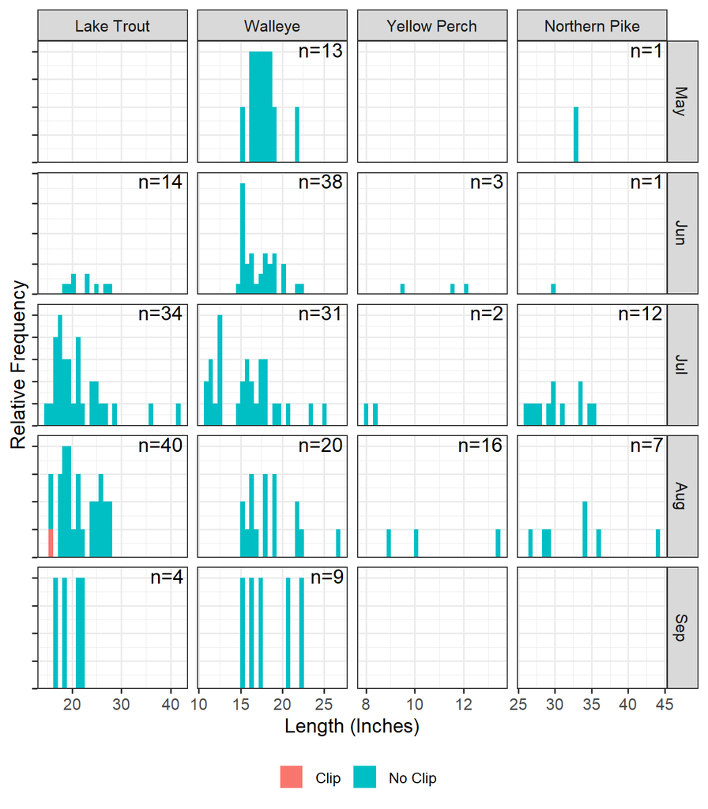

## Reproducibility Information

- **Compiled Date:** Tue Jun 11 2019
- **Compiled Time:** 10:40:07 PM
- **R Version:** R version 3.6.0 (2019-04-26)
- **System:** Windows, x86_64-w64-mingw32/x64 (64-bit)
- **Base Packages:** base, datasets, graphics, grDevices, grid, methods, stats, utils
- **Required Packages:** FSA, lubridate, tidyr, dplyr, magrittr, huxtable, kableExtra, captioner, ggplot2, patchwork, sugrrants, grid, haven, knitr, here, readxl, tibble and their dependencies (assertthat, car, cellranger, cli, crayon, digest, dunn.test, epitools, evaluate, fansi, forcats, generics, glue, gplots, graphics, grDevices, gtable, highr, hms, htmltools, lazyeval, lmtest, markdown, MASS, memoise, methods, mgcv, pillar, pkgconfig, plotrix, plyr, purrr, R6, Rcpp, readr, reshape2, rlang, rmarkdown, rprojroot, rstudioapi, rvest, scales, sciplot, stats, stringi, stringr, tidyselect, tools, utils, viridisLite, webshot, withr, xfun, xml2, yaml)
- **Other Packages:** captioner_2.2.3, dplyr_0.8.1, FSA_0.8.24.9000, ggplot2_3.1.1, haven_2.1.0, here_0.1, huxtable_4.5.0, kableExtra_1.1.0, knitr_1.22, lubridate_1.7.4, magrittr_1.5, patchwork_0.0.1, readxl_1.3.1, sugrrants_0.2.4, tibble_2.1.1, tidyr_0.8.3
- **Loaded-Only Packages:** assertthat_0.2.1, backports_1.1.4, cellranger_1.1.0, colorspace_1.4-1, compiler_3.6.0, crayon_1.3.4, digest_0.6.18, evaluate_0.13, forcats_0.4.0, generics_0.0.2, glue_1.3.1, gtable_0.3.0, hms_0.4.2, htmltools_0.3.6, httr_1.4.0, labeling_0.3, lazyeval_0.2.2, munsell_0.5.0, packrat_0.5.0, pillar_1.4.0, pkgconfig_2.0.2, plyr_1.8.4, purrr_0.3.2, R6_2.4.0, Rcpp_1.0.1, readr_1.3.1, reshape2_1.4.3, rlang_0.3.4, rmarkdown_1.12, rprojroot_1.3-2, rstudioapi_0.10, rvest_0.3.4, scales_1.0.0, stringi_1.4.3, stringr_1.4.0, tidyselect_0.2.5, tools_3.6.0, viridisLite_0.3.0, webshot_0.5.1, withr_2.1.2, xfun_0.7, xml2_1.2.0, yaml_2.2.0